# Reproducible Research_PA1

Paymon Hashemi

17 Sep 2015

## Loading and preprocessing the data

1. Load the data

```r
ActivityData <- read.csv("C:/Users/PAYMON/RepData_PeerAssessment1/activity/activity.csv")
```

2. Process/transform data into a format suitable for my analysis

```r
ActivityData$date <- as.Date(ActivityData$date, format = "%Y-%m-%d")
ActivityData$interval <- as.factor(ActivityData$interval)
```

3. Explore the data using str() and head ()

```r
str(ActivityData)
```

```
## 'data.frame':    17568 obs. of  3 variables:
##  $ steps   : int  NA NA NA NA NA NA NA NA NA NA ...
##  $ date    : Date, format: "2012-10-01" "2012-10-01" ...
##  $ interval: Factor w/ 288 levels "0","5","10","15",..: 1 2 3 4 5 6 7 8 9 10 ...
```

```r
head(ActivityData)
```

```
##   steps       date interval
## 1    NA 2012-10-01        0
## 2    NA 2012-10-01        5
## 3    NA 2012-10-01       10
## 4    NA 2012-10-01       15
## 5    NA 2012-10-01       20
## 6    NA 2012-10-01       25
```

## What is mean total number of steps taken per day?

0. Use tapply to develop a vector prior to developing a histogram plot

```r
StepsEachDay <- tapply(ActivityData$steps, ActivityData$date, sum, na.rm = TRUE)
```

1. Make a histogram of the total number of steps taken each day

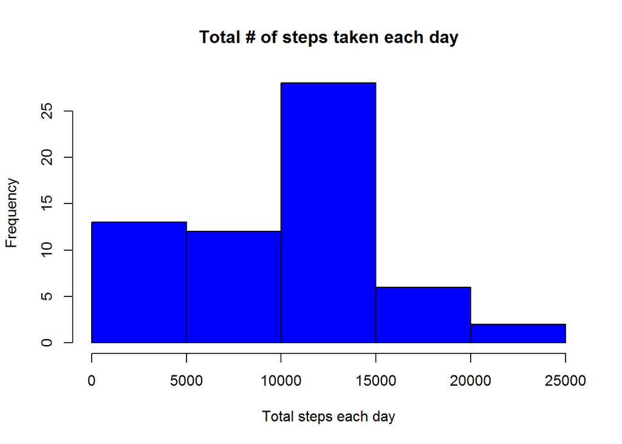

```r
hist(StepsEachDay, col="blue",
     xlab = 'Total steps each day', ylab= 'Frequency',
     main = "Total # of steps taken each day")
```

2. Calculate and report the mean and median total number of steps taken per day

```r
StepsMean <- mean(StepsEachDay, na.rm=TRUE)
StepsMean
```

```
## [1] 9354.23
```

```r
StepsMedian <- median(StepsEachDay, na.rm=TRUE)
StepsMedian
```

```
## [1] 10395
```

## What is the average daily activity pattern?

1. Make a time series plot

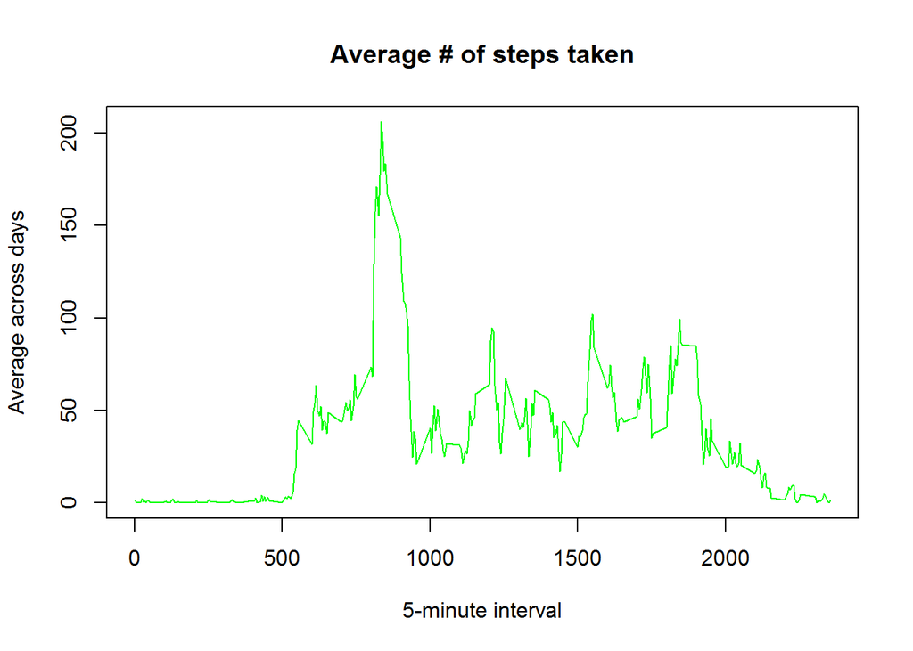

```r
TimeSeries <- tapply(ActivityData$steps, ActivityData$interval, mean, na.rm = TRUE)
plot(row.names(TimeSeries), TimeSeries, type = "l",
     xlab = "5-minute interval", ylab = "Average across days",
     main = "Average # of steps taken", col = "green")
```

2. Determine which 5-minute interval contains the maximum number of steps

```r
MaxInterval <- which.max(TimeSeries)
names(MaxInterval)
```

```
## [1] "835"
```

## Imputing missing values

1. Calculate and report the total number of missing values in the dataset

```r
ActivityData_NA <- sum(is.na(ActivityData))
ActivityData_NA
```

```
## [1] 2304
```

2. Devise a strategy for filling in all of the missing values in the dataset
3. Create a new dataset that is equal to the original, but with missing data filled in (Note: This is a combined step)

```r
library(Hmisc)
ActivityData_Imputed <- ActivityData
ActivityData_Imputed$steps <- impute(ActivityData$steps, fun=mean)
```

4. Make a histogram of the total number of steps taken each day

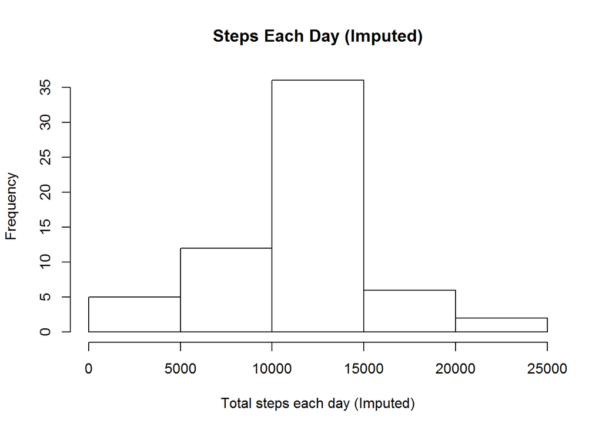

```r
StepsEachDay_Imputed <- tapply(ActivityData_Imputed$steps, ActivityData_Imputed$date, sum)
hist(StepsEachDay_Imputed,
     xlab = 'Total steps each day (Imputed)', ylab= 'Frequency',
     main = 'Steps Each Day (Imputed)')
```

5. Calculate and report the mean and median total number of steps taken per day

```r
StepsMean_Imputed <- mean(StepsEachDay_Imputed, na.rm=TRUE)
StepsMean_Imputed
```

```
## [1] 10766.19
```

```r
StepsMedian_Imputed <- median(StepsEachDay_Imputed, na.rm=TRUE)
StepsMedian_Imputed
```

```
## [1] 10766.19
```

## Are there differences in activity patterns between weekdays and weekends?

1. Create a new factor variable in the dataset with “Weekday” and “weekend” levels

```r
Day <- weekdays(ActivityData_Imputed$date)
DayType <- vector()
for (i in 1:nrow(ActivityData_Imputed)) {
        if (Day[i] == "Saturday") {
                DayType[i] <- "Weekend"
        } else if (Day[i] == "Sunday") {
                DayType[i] <- "Weekend"
        } else {
                DayType[i] <- "Weekday"
        }
}

ActivityData_Imputed$DayType <- DayType
ActivityData_Imputed$DayType <- factor(ActivityData_Imputed$DayType)

StepsDay <- aggregate(steps ~ interval + DayType, data = ActivityData_Imputed, mean)
names(StepsDay) <- c("interval", "DayType", "steps")
```

2. Make a panel plot containing a time series plot

```
## geom_path: Each group consist of only one observation. Do you need to adjust the group aesthetic?
## geom_path: Each group consist of only one observation. Do you need to adjust the group aesthetic?
```

[figure not shown]

```r
Imputed_TimeSeries <- aggregate(steps ~ interval + DayType, data=ActivityData_Imputed, mean)
ggplot(Imputed_TimeSeries, aes(x=interval, y=steps)) +
        geom_line() +
        facet_wrap(~ DayType, nrow=2, ncol=1) +
        xlab("5-minute interval") +
        ylab("Average # of steps")
```